# ITS Tutorial

KJ

2023-11-12

## Introduction to interrupted time series analysis

```r
# Load necessary libraries
library(tidyverse)  # For data manipulation
library(lubridate)  # For handling date-time data
library(broom)      # For tidying model outputs
#install.packages("tsModel") # For time series analysis
library(tsModel)
```

# Create a dummy variable

```r
# Load necessary library
library(lubridate)

# Set seed for reproducibility
set.seed(123)

# Create a sequence of monthly dates from January 2020 to December 2022
dates <- seq(from = as.Date("2020-01-01"), to = as.Date("2022-12-31"), by = "month")

# Generate random data for the outcome variable
outcome_variable <- rnorm(length(dates))

# Create an intervention variable (assuming an intervention at the midpoint)
intervention <- ifelse(dates < as.Date("2021-07-01"), 0, 1)

# Combine into a data frame
data_frame <- data.frame(date = dates, outcome_variable = outcome_variable, intervention = intervention)

# View the first few rows of the dummy data frame
head(data_frame)
```

```
##         date outcome_variable intervention
## 1 2020-01-01      -0.56047565            0
## 2 2020-02-01      -0.23017749            0
## 3 2020-03-01       1.55870831            0
## 4 2020-04-01       0.07050839            0
## 5 2020-05-01       0.12928774            0
## 6 2020-06-01       1.71506499            0
```

## Data preparation and handling missing values

Prepare your data by handling missing values and ensuring proper date formatting.

```r
# Handle missing values
data_frame $outcome_variable <- ifelse(is.na(data_frame$outcome_variable), mean(data_frame$outcome_variable, na.rm = TRUE), data_frame$outcome_variable)
```

This is what an ITS model looks like: its_model <- lm(outcome_variable ~ time_variable + intervention_factor + time_since_intervention, data = data_frame)

If your data frame data_frame contains a variable named date and you want to create the variables time_variable, as.factor(intervention), and time_since_intervention, you can follow these steps:

Assuming date is a timestamp, we can create the time_variable as the difference in time from the start date. Additionally, we can create a factor variable for intervention and calculate time_since_intervention. Here’s an example:

```r
# Assuming 'date' is in Date format, you may need to adjust if it's in a different format
data_frame$date <- as.Date(data_frame$date)

# Create time_variable as the difference in time from the start date
data_frame$time_variable <- as.numeric(difftime(data_frame$date, min(data_frame$date), units = "days"))

# Create as.factor(intervention)
data_frame$intervention_factor <- as.factor(data_frame$intervention)

# Create time_since_intervention
data_frame$time_since_intervention <- ifelse(data_frame$intervention == 1, data_frame$time_variable, 0)
```

## Assumptions and requirements for ITS analysis with ARIMA models

# Step 1: Checking for Stationarity

The data must be stationary for an ARIMA model. Stationarity means that the statistical properties of the process generating the time series do not change over time. You can use the Augmented Dickey-Fuller (ADF) test to check for stationarity.

```r
# Check for stationarity (an assumption of ITS)
library(tseries)
# Apply the Augmented Dickey-Fuller Test
adf.test(data_frame$outcome_variable, alternative = "stationary")
```

```
##
##  Augmented Dickey-Fuller Test
##
## data:  data_frame$outcome_variable
## Dickey-Fuller = -2.0188, Lag order = 3, p-value = 0.5658
## alternative hypothesis: stationary
```

```r
# Interpretation:
# If the p-value is low (typically < 0.05), the null hypothesis of a unit root is rejected, indicating stationarity.
```

# Step 2: Determining the order of differencing (d)

You need to find the right level of differencing (d) to make the series stationary if it’s not already.

```r
# Use ndiffs() to find the appropriate differencing order
library(forecast)
d <- ndiffs(data_frame$outcome_variable)

# Interpretation:
# The value of d is the recommended number of differences required for stationarity.
```

If the result of ndiffs(data_frame$outcome_variable) suggests that differencing is needed (i.e., d>0), and after applying the initial differencing, the time series is still not stationary, you should continue differencing until stationarity is achieved. You can do this by incrementing the order of differencing and re-evaluating stationarity using methods like the Augmented Dickey-Fuller (ADF) test.

```r
# Initial differencing

diff1 <- diff(data_frame$outcome_variable)

data_frame$diff1<-c(NA,diff1)

# Check stationarity after the first differencing
adf_test_result_diff1 <- adf.test(na.omit(data_frame$diff1), alternative = "stationary")
# Print the results
print(adf_test_result_diff1)
```

```
##
##  Augmented Dickey-Fuller Test
##
## data:  na.omit(data_frame$diff1)
## Dickey-Fuller = -5.1907, Lag order = 3, p-value = 0.01
## alternative hypothesis: stationary
```

```r
# If the series is still not stationary, continue differencing
if (adf_test_result_diff1$p.value > 0.05) {
  # Incremental differencing
  data_frame$diff2 <- diff(data_frame$diff1)

  # Check stationarity after the second differencing
  adf_test_result_diff2 <- adf.test(data_frame$diff2, alternative = "stationary")

  # Print the results
  print(adf_test_result_diff2)

  # Repeat as needed
}
```

# Step 3: Identifying the Order of AR (p) and MA (q) components

Autocorrelation Function (ACF) and Partial Autocorrelation Function (PACF) plots are used to identify potential AR and MA terms.

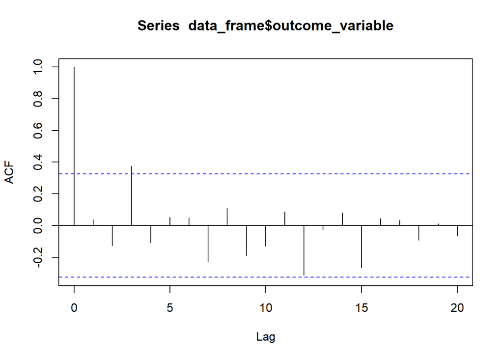

```r
# ACF and PACF plots
acf(data_frame$outcome_variable, lag.max = 20)
```

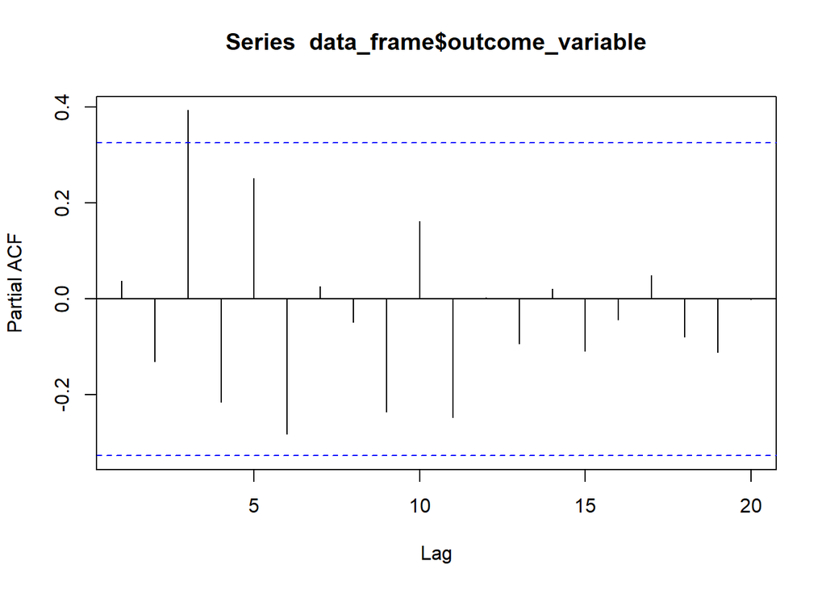

```r
pacf(data_frame$outcome_variable, lag.max = 20)
```

```r
# Interpretation:
# The number of significant lags in the PACF after differencing indicates the AR order (p).
# The number of significant lags in the ACF after differencing indicates the MA order (q).
```